# Ggplot2 Tutorial

## **`geom_histogram`**

`geom_histogram()` is often used when plotting a continuous variable.

Here is a basic example of the `geom_histogram()` function with the penguins dataset.

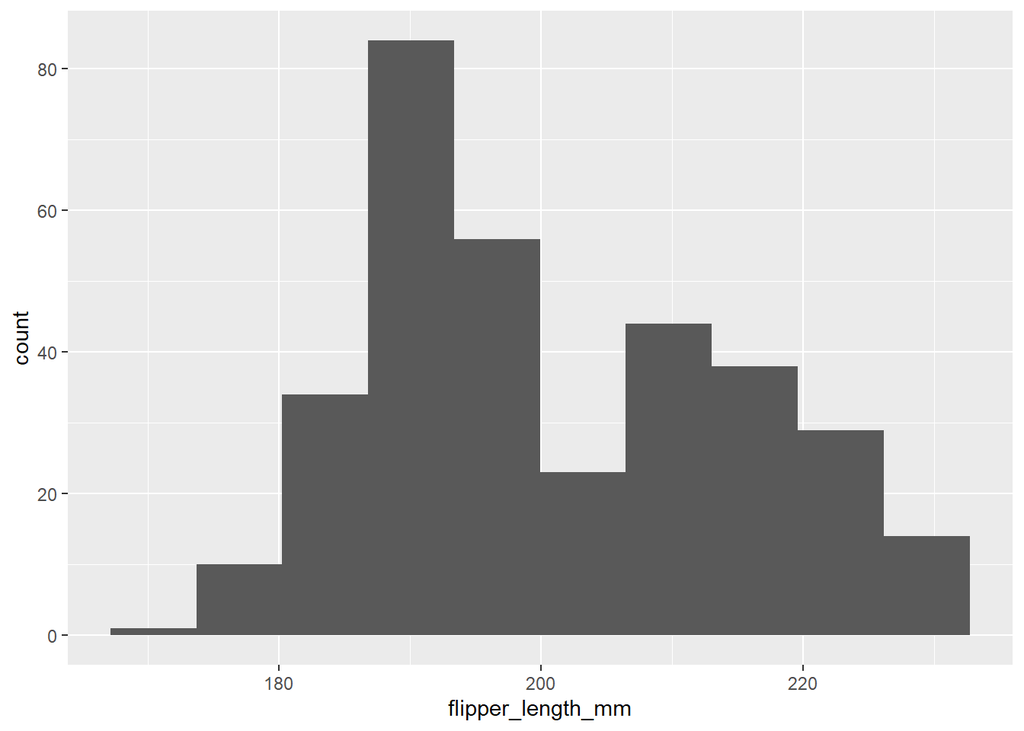

```r
#basic histogram for flipper length
ggplot(new_penguins) +
  aes(x = flipper_length_mm) +
  geom_histogram(bins = 10)
```

In this histogram, you are also able to compare the flipper length by species using the color or fill argument within aesthetics.

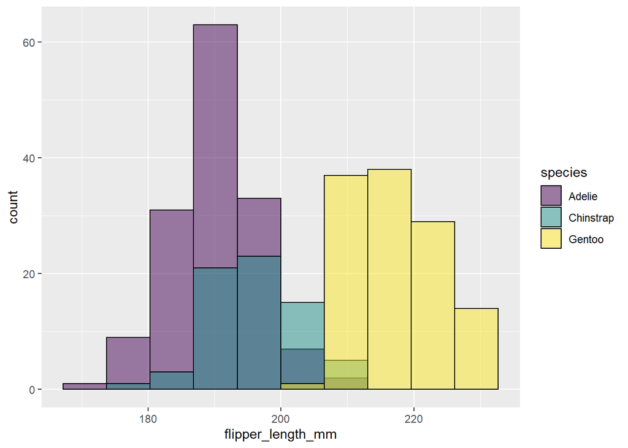

```r
#histogram for flipper length by species
ggplot(new_penguins) +
  aes(x = flipper_length_mm,
      fill = species) +
  geom_histogram(alpha = .5, position = "identity", color = "black", bins = 10) +
  scale_fill_viridis_d()
```

### **Facets**

Another way to look at flipper length by species would be to use facets, which splits the plot into panels.

The way to use facets is either by `facet_grid()` or `facet_wrap`.

#### **`facet_grid()`**

`facet_grid()` plots the variables in a 2d grid, either by `. ~ <variable>` or `<variable> ~ .`.

- `. ~ <variable>`
  - spreads the values of the variable across columns, having the vertical scales aligned.
- `<variable> ~ .`
  - spreads the values of the variable across rows, having the horizontal scales aligned.

#### **`facet_wrap()`**

`facet_wrap()` creates the ribbon of panels that are generated by the levels of the variables.

This function can be especially useful when there are many levels in one variable, and you are trying to save space on your graphs.

Below are two histograms comparing facet grid to facet wrap.

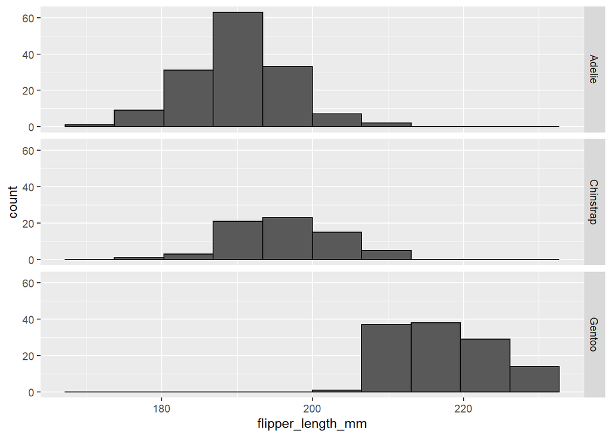

```r
#flipper length by species in histogram using facet grid
ggplot(new_penguins) +
  aes(x = flipper_length_mm) +
  geom_histogram(color = "black", bins = 10) +
  facet_grid(species ~ .)
```

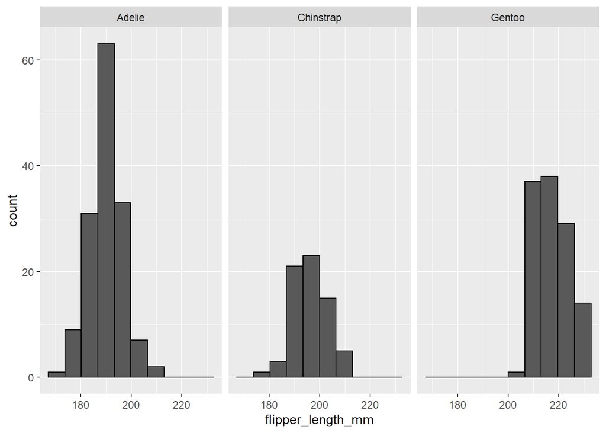

```r
#flipper length by species in histogram using facet wrap
ggplot(new_penguins) +
  aes(x = flipper_length_mm) +
  geom_histogram(color = "black", bins = 10) +
  facet_wrap(~ species)
```

Based on these histograms, `facet_grid()` seems better suited to illustrate our data in a meaningful way. I am able to compare the flipper length by species more directly by aligning the horizontal scales. Since there are only three levels of the species variable, facet wrap is not needed to save space.

### **Setting the bins**

I set the number of bins to 10 using Sturge’s Rule. The formula is:

$$K = 1 + 3.322 log_N$$
K = number of bins.

N = number of observations in data.

## **`geom_density`**

The `geom_density()` function plots the distribution of a numeric variable.

Here is a basic example of using the `geom_density()` function with the penguins data set.

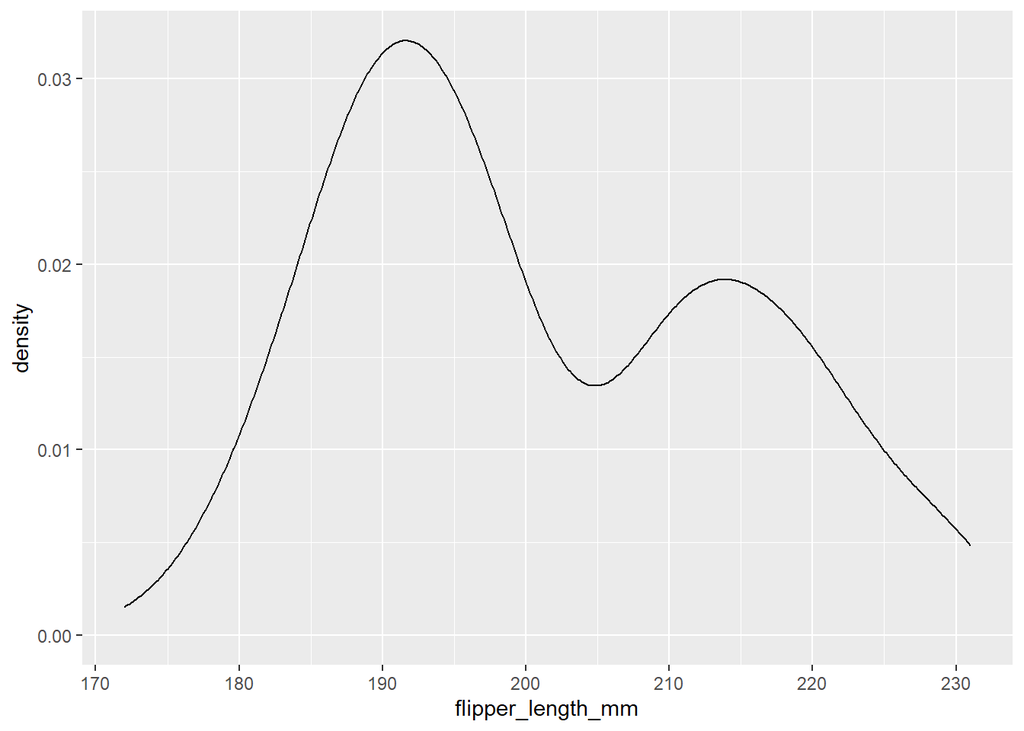

```r
#basic density plot for flipper length
ggplot(new_penguins) +
  aes(x = flipper_length_mm) +
  geom_density()
```

### **Using density plot with histograms**

You’re able to combine multiple plots together on the same scale, such as density and histogram plots. To do this, plot the histogram with density on the y-axis instead of count.

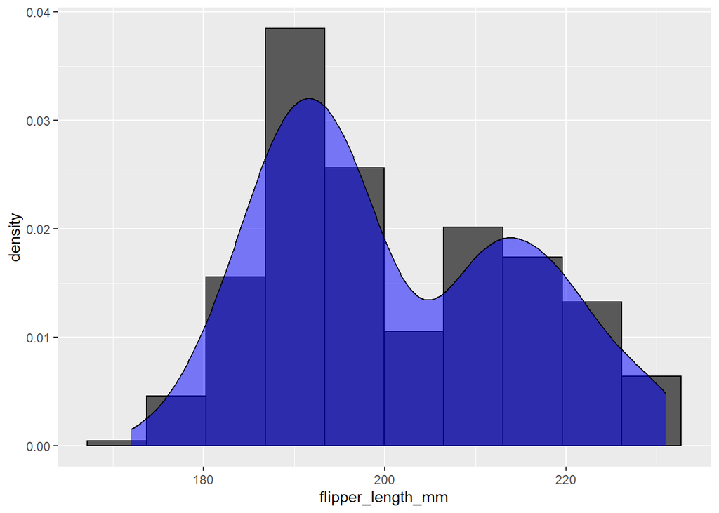

```r
#density and histogram plot
ggplot(new_penguins) +
  aes(x = flipper_length_mm) +
  geom_histogram(aes(y = ..density..), color = "black", bins = 10) +
  geom_density(alpha = .5, fill = "blue")
```